# 7_2_Classical_Decomposition

# References

NOTE: this material is not original, but rather an extension of the following reference, which is publicly available.

1. Hyndman, R.J., & Athanasopoulos, G., 2021. *Forecasting: principles and practice*. 3rd edition.

# Packages

```r
library(fpp3)
```

# Classical decomposition:

It is the starting point for most other mehods of time series decomposition.

2 forms of classical decomposition:

- Additive
- Multiplicative

The actual algorithm depends on whether the seasonal period is even or uneven:

- Even seasonal period $m$: trend approximated by a 2x$m$ moving average.
- Uneven seasonal period $m$: trend approximated by an $m$ moving average.

# Additive decomposition:

## Step 1 - Estimate trend

If $m$ is an even number, compute the trend-cycle component $\hat{T_t}$ using 2 x $m$-MA. If $m$ is an odd number compute the trend-cycle component $\hat{T_t}$ using an $m$-MA.

## Step 2 - Detrended series

Calculate the de-trended series: $y_t - \hat{T_t}$

## Step 3 - Compute seasonal component

We will make the **underlying assumption** that the seasonal component remains the same for every season. This is one of the main weaknesses of the classical decomposition.

1. Average the de-trended values for each component of the season.
   - Example: with monthly data the seasonal component for march is the average of all the detrended March values in the data
2. Adjust the seasonal component **values to ensure they add to 0**. This ensures that the average of the seasonal component over one period is 0.

   2.1 Sum the seasonal components of everymonth. The result is the total deviation from 0 of the sum of the seasonal components.

   2.2 Divide the previous result by the seasonal period and substract that amount from each seasonal component.

By doing this, over one period the seasonal component will not contribute to the average value of the series:. If $m$ is the length of the seasonal period we have:

$$\sum_{i=1}^{m} S_i= 0$$

$$\frac{\sum_{i=1}^m(T_i + S_i + R_i)}{m} \underset{\underset{\sum_{i=1}^mS_i = 0}{\uparrow}}{=} \frac{\sum_{i=1}^m(T_i + R_i)}{m}$$

## Step 4 - Compute the remainder component

$\hat{R} = y_t - \hat{T_t} - \hat{S_t}$

## Example: computation using the function `classical_decomposition()`:

```r
# Filter the series and select relevant columns
us_retail_employment <- us_employment %>%
  filter(year(Month) >= 1990, Title == "Retail Trade") %>%
  select(-Series_ID)

# Let us compute the classical decomposition using the function in the feasts library:
classical_dec <- us_retail_employment %>%
  model(
    classical_decomposition(Employed, type = "additive")
  ) %>%
  components()

select(classical_dec, Month, Employed, trend, seasonal, random)
```

```
## # A tsibble: 357 x 5 [1M]
##       Month Employed  trend seasonal random
##       <mth>    <dbl>  <dbl>    <dbl>  <dbl>
##  1 1990 Jan   13256.    NA    -75.5   NA
##  2 1990 Feb   12966.    NA   -273.    NA
##  3 1990 Mar   12938.    NA   -253.    NA
##  4 1990 Apr   13012.    NA   -190.    NA
##  5 1990 May   13108.    NA    -88.9   NA
##  6 1990 Jun   13183.    NA    -10.4   NA
##  7 1990 Jul   13170. 13178.   -13.3    5.65
##  8 1990 Aug   13160. 13161.    -9.99   8.80
##  9 1990 Sep   13113. 13141.   -87.4   59.9
## 10 1990 Oct   13185. 13117.    34.6   33.8
## # ... with 347 more rows
```

## Example: manual computation implementing the described algorithm.

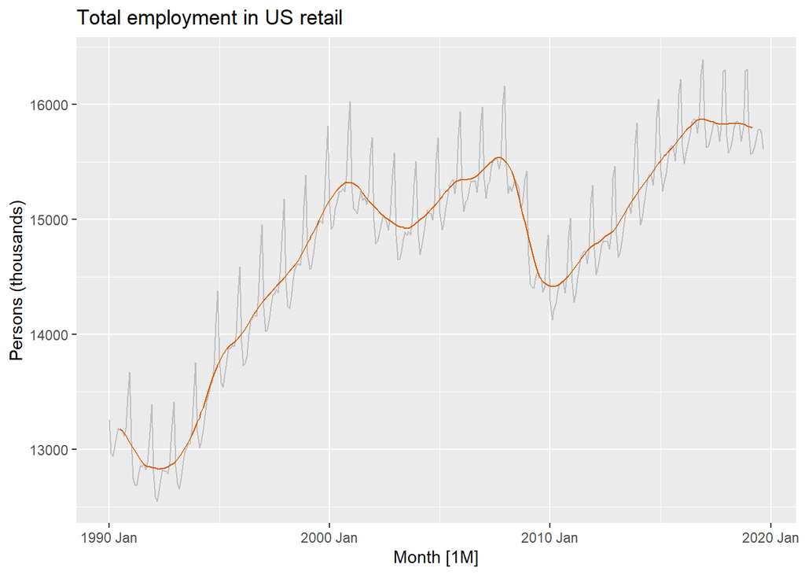

```r
# Compute moving averages
# Because the seasonal period is 12, we need a 2x12-MA
manual_decomposition <- us_retail_employment %>%
  mutate(
    `12-MA` = slider::slide_dbl(Employed, mean,
                .before = 5, .after = 6, .complete = TRUE),
    `2x12-MA` = slider::slide_dbl(`12-MA`, mean,
                .before = 1, .after = 0, .complete = TRUE)
  )

# Plot the computed trend
manual_decomposition %>%
  autoplot(Employed, colour = "gray") +
  geom_line(aes(y = `2x12-MA`), colour = "#D55E00") +
  labs(y = "Persons (thousands)",
       title = "Total employment in US retail")
```

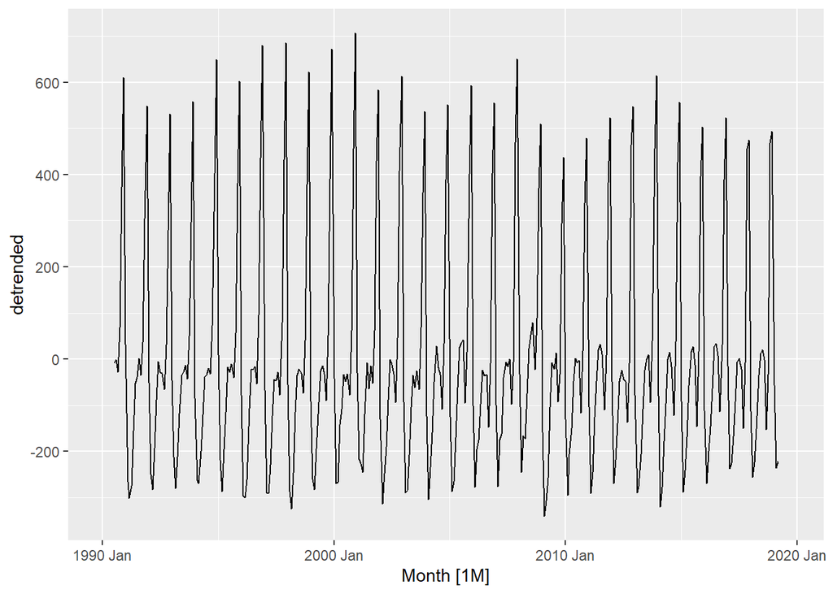

```r
# Compute the detrended component:
manual_decomposition <- manual_decomposition %>%
  mutate(detrended = Employed - `2x12-MA`,
         n_month = month(Month)) # Add an identifier for the month (used later for a join statement)

manual_decomposition %>% autoplot(detrended)
```

This is the resulting detrended component, which contains the seasonal + remainder component

Now we will compute the seasonal component

```r
res <- manual_decomposition %>%
  index_by(n_month = month(Month)) %>%

  #Compute seasonal component
  summarise(
    seasonal_c = mean(detrended, na.rm = TRUE)
  ) %>%

  ungroup()

res
```

```
## # A tsibble: 12 x 2 [1]
##    n_month seasonal_c
##      <dbl>      <dbl>
##  1       1      -75.5
##  2       2     -273.
##  3       3     -253.
##  4       4     -190.
##  5       5      -88.9
##  6       6      -10.4
##  7       7      -13.3
##  8       8      -10.0
##  9       9      -87.4
## 10      10       34.6
## 11      11      394.
## 12      12      573.
```

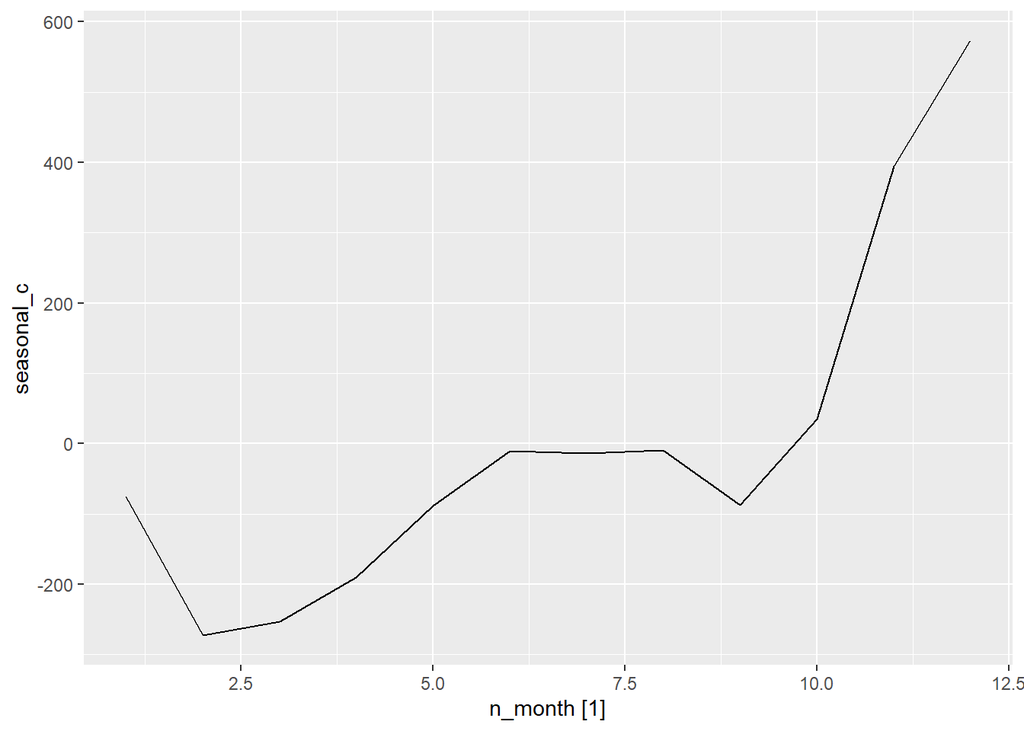

```r
#Check the aspect of the obtained seasonal component
res %>%
  autoplot(seasonal_c)
```

This is the resulting seasonal component of our decomposition.

- The first point is the value of the seasonal component for January
- The second point is the value of the seasonal component for February
- The third point is the value of the seasonal component for March
- …

Let us check if the values of the component add up to 0 as we wanted to impose:

```r
#The sum does not add up to 0
sum(res$seasonal_c)
```

```
## [1] -0.2273091
```

We can see that the sum is not 0. We will divide the sum by the period of the seasonal component (in this case 12) and then distribute this deviation from 0 evenly over the seasonal component.

```r
res <- res %>%
  # Correction so that the sum of the seasoan components is 0
  mutate(seasonal_c = seasonal_c  - sum(seasonal_c)/12)

sum(res$seasonal_c)
```

```
## [1] 5.329071e-15
```

As you can see, the seasonal component is now 0. Great. Let us bring the seasonal component back into our original dataset. For this we will use a join. Remember that we created previously a column called “n_month” that now comes in handy when doing this join:

```r
# Bring seasonal component into the dataset (I chose to use a "join" statement, very convenient)
manual_decomposition <- left_join(manual_decomposition, res, by = "n_month")
manual_decomposition
```

```
## # A tsibble: 357 x 8 [1M]
##       Month Title        Employed `12-MA` `2x12-MA` detrended n_month seasonal_c
##       <mth> <chr>           <dbl>   <dbl>     <dbl>     <dbl>   <dbl>      <dbl>
##  1 1990 Jan Retail Trade   13256.     NA        NA      NA          1     -75.5
##  2 1990 Feb Retail Trade   12966.     NA        NA      NA          2    -273.
##  3 1990 Mar Retail Trade   12938.     NA        NA      NA          3    -253.
##  4 1990 Apr Retail Trade   13012.     NA        NA      NA          4    -190.
##  5 1990 May Retail Trade   13108.     NA        NA      NA          5     -88.9
##  6 1990 Jun Retail Trade   13183.  13186.       NA      NA          6     -10.4
##  7 1990 Jul Retail Trade   13170.  13170.    13178.     -7.66       7     -13.3
##  8 1990 Aug Retail Trade   13160.  13151.    13161.     -1.20       8      -9.99
##  9 1990 Sep Retail Trade   13113.  13130.    13141.    -27.5        9     -87.4
## 10 1990 Oct Retail Trade   13185.  13103.    13117.     68.5       10      34.6
## # ... with 347 more rows
```

Now that we have the seasonal component, we obtain the remainder component by subtracting it from the de-trended component:

```r
# Compute remainder component:
manual_decomposition <- manual_decomposition %>%
  mutate(remainder = detrended - seasonal_c)

select(manual_decomposition, Month, `2x12-MA`, seasonal_c, remainder)
```

```
## # A tsibble: 357 x 4 [1M]
##       Month `2x12-MA` seasonal_c remainder
##       <mth>     <dbl>      <dbl>     <dbl>
##  1 1990 Jan       NA      -75.5      NA
##  2 1990 Feb       NA     -273.       NA
##  3 1990 Mar       NA     -253.       NA
##  4 1990 Apr       NA     -190.       NA
##  5 1990 May       NA      -88.9      NA
##  6 1990 Jun       NA      -10.4      NA
##  7 1990 Jul    13178.     -13.3       5.65
##  8 1990 Aug    13161.      -9.99      8.80
##  9 1990 Sep    13141.     -87.4      59.9
## 10 1990 Oct    13117.      34.6      33.8
## # ... with 347 more rows
```

We have all the components. We are now going to compute the maximum absolute errors of our manual computation, comparing it with the result provided by the function `classical_decomposition()`

```r
# Evaluation of absolute errors
max_err_seasonal = max(classical_dec$seasonal - manual_decomposition$seasonal_c, na.rm = TRUE)
max_err_trend = max(classical_dec$trend - manual_decomposition$`2x12-MA`, na.rm = TRUE)
max_err_rand = max(classical_dec$random - manual_decomposition$remainder, na.rm = TRUE)

max(c(max_err_seasonal, max_err_trend, max_err_rand))
```

```
## [1] 6.025402e-12
```

**QUESTION** Can you provide an interpretation of this result?

The result is not 0 but it is sufficiently close to 0 so that we can attribute this deviation to numerical errors (particularly given the fact that this error is much smaller than any of the components we have computed).

# Multiplicative decomposition:

In this case substractions are simply replaced by divisions

## Step 1 - Estimate trend

If $m$ is an even number, compute the trend-cycle component $\hat{T_t}$ using 2 x $m$-MA. If $m$ is an odd number compute the trend-cycle component $\hat{T_t}$ using an $m$-MA.

## Step 2 - Detrended series

Calculate the de-trended series: $y_t / \hat{T_t}$

## Step 3 - Compute seasonal component

We will make the **underlying assumption** that the seasonal component remains the same for every season. This is one of the main weaknesses of the classical decomposition.

1. Average the de-trended values for each component of the season.
   - Example: with monthly data the seasonal component for march is the average of all the detrended March values in the data
2. **Adjust the seasonal component values to ensure they add to $m$**. This ensures that the average of the seasonal component over one period is 1.

   2.1 Sum the seasonal components of everymonth. The result is the total deviation from 0 of the sum of the seasonal components.

   2.2 Divide the previous result by the seasonal period and substract that amount from each seasonal component.

Since the seasonal components add to $m$, the average of the time series over one period is a weighted average of the product of the trend and the remainder components, with the seasonal components divided by $m$ as weights that add to 1.In this case the weighted average is not symmetrical. If $m$ is the length of the seasonal period we have:

$$\sum_{i=1}^m{S_i} = m$$
$$\frac{\sum_{i=1}^m(T_i S_i R_i)}{m} = \underbrace{\sum_{i=1}^m\frac{Si}{m}(T_i R_i) }_{weighted\;mov.\;av.\\ of\;R_iT_i\;since\sum_{i=1}^mS_i/m = 1}$$

## Step 4 - Compute the remainder component

$\hat{R} = y_t /\hat{T_t}\hat{S_t}$

# Comments on classical decomposition:

Classical decomposition is still widely used, but it is not recommended. It is however the foundation for many of the other methods and understanding it is important. Some problems with classical decomposition are summarised below:

- Because the trend-cycle is approximated using centered moving averages, there is no estimate of the trend-cycle or the remainder component for the few first and last observations.
- The trend-cycle estimate tends to over-smooth rapid rises and falls in the data.
- **Assumes that the seasonal component repeats from year to year**.
  - For many series this is reasonable
  - For other longer series it is not. For example, electricity demand patterns have changed over time as air conditioning has become more available. This has shifted the maximum of the seasonal component from winter to summer.
- The classical decomposition method is not robust enough against unusual values or outliers in the series.

# Seasonally adjusted data:

The seasonally adjusted data is the reslt of **removing the seasonal component from the original data**

- *Additive decomposition*: $y_t - St$
- *Multiplicative decomposition*: $y_t / S_t$

It contains **the rmainder as well as the trend-cucle component*. Therefore they are not “smooth”. “Downturns” or “upturms” can be misleading.

- If you want to **look for turning poins and interpret changes in direction**, it is best to **use the trend cycle component** rather than the seasonally adjusted data

The seasonally adjusted data is **useful if the variation due to seasonality is not of primary interest**.

- Example: **unemployment data are usually seasonally adjusted** in order to **highlight variation due to the underlying state of the economy rather than the seasonal variation**

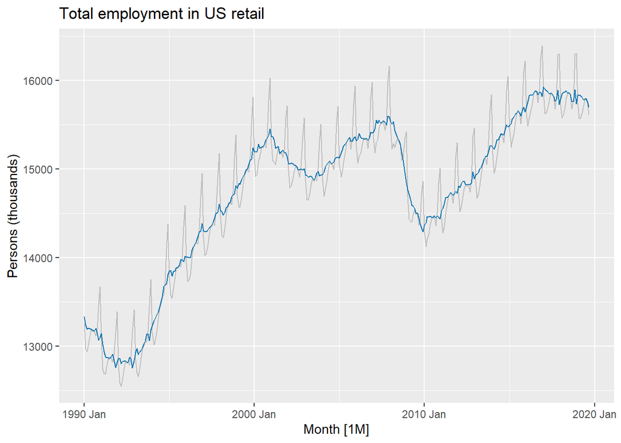

```r
classical_dec %>%
  as_tsibble() %>%
  autoplot(Employed, colour = "gray") +
  geom_line(aes(y=season_adjust), colour = "#0072B2") +
  labs(y = "Persons (thousands)",
       title = "Total employment in US retail")
```

# Homework

Consider the last five years of the Gas data from `aus_production`

```r
gas <- tail(aus_production, 5*4) %>% select(Gas)
gas
```

```
## # A tsibble: 20 x 2 [1Q]
##      Gas Quarter
##    <dbl>   <qtr>
##  1   221 2005 Q3
##  2   180 2005 Q4
##  3   171 2006 Q1
##  4   224 2006 Q2
##  5   233 2006 Q3
##  6   192 2006 Q4
##  7   187 2007 Q1
##  8   234 2007 Q2
##  9   245 2007 Q3
## 10   205 2007 Q4
## 11   194 2008 Q1
## 12   229 2008 Q2
## 13   249 2008 Q3
## 14   203 2008 Q4
## 15   196 2009 Q1
## 16   238 2009 Q2
## 17   252 2009 Q3
## 18   210 2009 Q4
## 19   205 2010 Q1
## 20   236 2010 Q2
```

1. Use `classical_decomposition` with `type=multiplicative` to calculate the trend-cycle and seasonal indices
2. Compute and plot the seasonally adjusted data.
3. Compute manually the classical decomposition of the series (as we did in class, but keep in mind that this scheme is multiplicative and that now the seasonal period is 4 instead of 12).

NOT TO BE SOLVED (solution will be provided):

4. Change one observations to be an outlier (e.g., add 300 to one observation), and recompute the seasonally adjusted data. What is the effect of the outlier?
5. Does it make any difference if the outlier is near the end rather than in the middle of the series?